# Customer Segmentation with K-Means

MARK5400 | Geico Insurance Practice Assignment

Author

Practice Project

**Learning goals**

Use **R** to compute Euclidean distance, run K-Means clustering, inspect centroids, plot customer groups, and use the elbow method to compare cluster counts. The 12 customers below are **simulated learning data**, not real Geico customers.

## 1 1. Business problem

**Research question:** How should an insurance company group customers based on what matters to them?

Each customer gives a rating from **1 (not important)** to **10 (very important)** for:

- **Premium Savings:** How important are lower insurance premiums?
- **Neighborhood Agent:** How important is having a nearby insurance agent?

## 2 2. Create the dataset

```r
customers <- data.frame(
  Customer = LETTERS[1:12],
  Premium_Savings = c(9, 8, 9, 8, 2, 3, 1, 2, 7, 8, 6, 7),
  Neighborhood_Agent = c(2, 3, 3, 1, 9, 8, 9, 7, 8, 9, 8, 9)
)
knitr::kable(customers)
```

Table 1: Simulated insurance customer preferences

| Customer | Premium_Savings | Neighborhood_Agent |
| --- | --- | --- |
| A | 9 | 2 |
| B | 8 | 3 |
| C | 9 | 3 |
| D | 8 | 1 |
| E | 2 | 9 |
| F | 3 | 8 |
| G | 1 | 9 |
| H | 2 | 7 |
| I | 7 | 8 |
| J | 8 | 9 |
| K | 6 | 8 |
| L | 7 | 9 |

## 3 3. Calculate Euclidean distance

The distance between customers A and E is:

`Distance = sqrt((Savings_A - Savings_E)^2 + (Agent_A - Agent_E)^2)`

```r
d_AE <- sqrt(
  (customers$Premium_Savings[1] - customers$Premium_Savings[5])^2 +
  (customers$Neighborhood_Agent[1] - customers$Neighborhood_Agent[5])^2
)
cat("Distance between A and E:", round(d_AE, 2), "\n")
```

```
Distance between A and E: 9.9
```

A **smaller** distance indicates **more similar** preference ratings.

## 4 4. Run K-Means (K = 3)

K is the number of groups. K-Means repeatedly **assigns customers to the nearest centroid** and then **updates each centroid** until the groups stabilize.

```r
x <- customers[, c("Premium_Savings", "Neighborhood_Agent")]
set.seed(123)
fit <- kmeans(x, centers = 3, nstart = 25)
customers$Cluster <- fit$cluster

# Cluster numbers are arbitrary labels.
knitr::kable(customers[order(customers$Cluster), ],
             caption = "Customer group assignments")
```

Customer group assignments

| Customer | Premium_Savings | Neighborhood_Agent | Cluster |
| --- | --- | --- | --- |
| A | 9 | 2 | 1 |
| B | 8 | 3 | 1 |
| C | 9 | 3 | 1 |
| D | 8 | 1 | 1 |
| E | 2 | 9 | 2 |
| F | 3 | 8 | 2 |
| G | 1 | 9 | 2 |
| H | 2 | 7 | 2 |
| I | 7 | 8 | 3 |
| J | 8 | 9 | 3 |
| K | 6 | 8 | 3 |
| L | 7 | 9 | 3 |

```r
knitr::kable(round(fit$centers, 2),
             caption = "Cluster centroids (mean preferences)")
```

Cluster centroids (mean preferences)

| Premium_Savings | Neighborhood_Agent |
| --- | --- |
| 8.5 | 2.25 |
| 2.0 | 8.25 |
| 7.0 | 8.50 |

```r
cat("Customers in each cluster:", fit$size, "\n")
```

```
Customers in each cluster: 4 4 4
```

## 5 5. Plot the customer groups

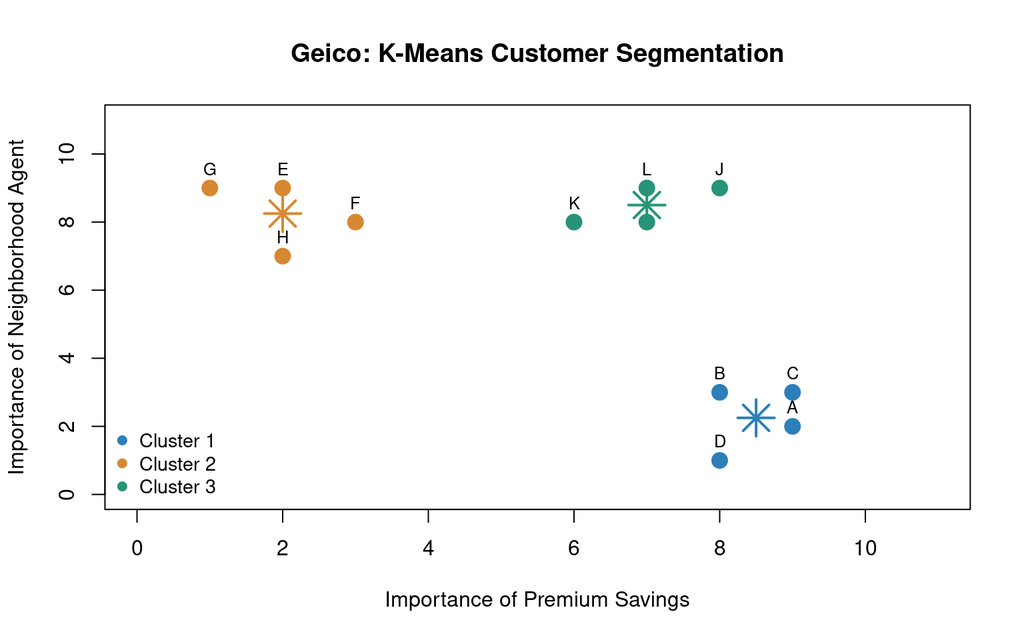

Figure 1: Three groups of simulated insurance customers. Stars mark centroids.

```r
colors <- c("#2C7FB8", "#D78832", "#279477")
plot(
  x$Premium_Savings, x$Neighborhood_Agent,
  col = colors[fit$cluster], pch = 19, cex = 1.6,
  xlim = c(0, 11), ylim = c(0, 11),
  xlab = "Importance of Premium Savings",
  ylab = "Importance of Neighborhood Agent",
  main = "Geico: K-Means Customer Segmentation"
)
text(x$Premium_Savings, x$Neighborhood_Agent,
     labels = customers$Customer, pos = 3, cex = 0.8)
points(fit$centers[, 1], fit$centers[, 2],
       col = colors[1:3], pch = 8, cex = 2.7, lwd = 2)
legend("bottomleft", legend = paste("Cluster", 1:3),
       col = colors[1:3], pch = 19, bty = "n", cex = 0.9)
```

**Interpretation**

Three meaningful preference profiles emerge: **high savings / low agent**, **low savings / high agent**, and **high savings / high agent**. Identify each profile by its **centroid values**, not by the arbitrary cluster number.

## 6 6. Choose K using the elbow method

**Within-cluster sum of squares (WSS)** measures how far observations are from their assigned centers. When K increases, WSS decreases or stays the same. Look for a bend where improvement starts to slow.

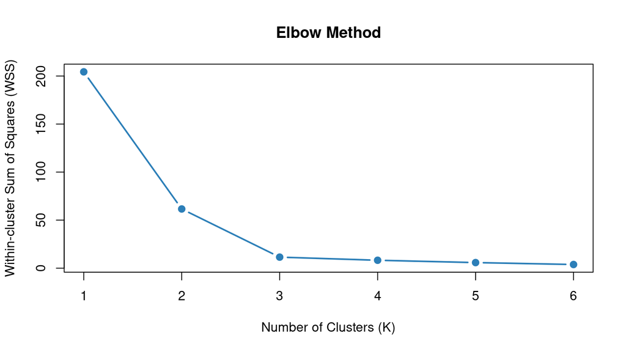

Figure 2: Elbow plot: total within-cluster sum of squares against K.

```r
set.seed(123)
k_values <- 1:6
wss <- sapply(k_values, function(k) {
  kmeans(x, centers = k, nstart = 25)$tot.withinss
})
plot(k_values, wss, type = "b", pch = 19, col = "#2C7FB8", lwd = 2,
     xlab = "Number of Clusters (K)",
     ylab = "Within-cluster Sum of Squares (WSS)",
     main = "Elbow Method")
```

**Important:** The elbow rule is a heuristic, not a guarantee that one K is mathematically correct.

## 7 7. Marketing decisions

| Customer preference profile | Possible marketing action |
| --- | --- |
| High savings, low agent | Low-premium digital self-service plan |
| Low savings, high agent | Local agent access and personalized support |
| High savings, high agent | Affordable plan with optional human assistance |

These are **illustrative recommendations**, not measured treatment effects.

## 8 8. Homework questions

1. Calculate the Euclidean distance between customers **A and E**.
2. Describe the **centroid** of each cluster in plain English.
3. Explain why K-Means repeats assignment and centroid updating **until convergence**.
4. What does the **elbow method** suggest about the choice of K here?
5. Suggest one **targeted marketing strategy** for each customer group.

*Reproducibility:* All computations and plots are generated from the R chunks above. No packages beyond R and the R/Quarto rendering environment (including knitr) are needed.